# 機器學習簡介

## 郭耀仁

## 需要哪些前置作業

- Gmail 帳號（為了使用 [Google Colab](https://colab.research.google.com/notebooks/welcome.ipynb)）
- 會操作 Jupyter Notebook 或 [Google Colab](https://colab.research.google.com/notebooks/welcome.ipynb)
- Python 程式設計
- 瞭解 `numpy` 與矩陣運算
- 瞭解 `pandas` 的 `Series` 與 `DataFrame`
- 瞭解 `matplotlib.pyplot`

## 機器學習的定位

[figure not shown]

Source: [rapidminer](https://rapidminer.com/artificial-intelligence-machine-learning-deep-learning/)

## 定義機器學習

[Arthur Samuel](https://en.wikipedia.org/wiki/Arthur_Samuel)

> The field of study that gives computers the ability to learn without being explicitly programmed.

## 定義機器學習（2）

[Tom Mitchell](http://www.cs.cmu.edu/~tom/)

> A computer program is said to learn from experience E with respect to some class of tasks T and performance measure P, if its performance at tasks in T, as measured by P, improves with experience E.

## 定義機器學習（3）

[林軒田](http://www.csie.ntu.edu.tw/~htlin/)

> 我們從小是怎麼樣辨認一棵樹的，是爸爸媽媽告訴我們一百條規則來定義嗎？其實不是的，很大一部分是透過我們自己的觀察很多的樹與不是樹之後，得到並且內化了辨認一棵樹的技巧，機器學習想要做的就是一樣的事情。

## 機器學習的種類

- 監督式學習（Supervised Learning）：具有目標變數的 Labeled data
  - 迴歸問題：目標變數是連續型（數值），像是股價、氣溫、匯率、房價...等
  - 分類問題：目標變數是離散型（類別），像是垃圾郵件/非垃圾郵件、[熱狗/非熱狗](https://youtu.be/vIci3C4JkL0)...等
- 非監督式學習（Unsupervised Learning）：沒有目標變數的 Unlabeled data
  - 聚類問題：客戶分群
  - 降維問題：主成份分析

## 認識 Scikit-Learn

- 用來實作資料探勘與機器學習的 Python 套件
- 建構於 NumPy，SciPy 與 Matplotlib 套件之上
- 有[六大功能模組](http://scikit-learn.org/stable/index.html)：
  - 預處理
  - 降維
  - 迴歸
  - 分群
  - 分類
  - 模型評估

## 認識 Scikit-Learn（2）

- [其他的 Scikits](https://scikits.appspot.com/scikits)
- [Scikit-Learn 機器學習地圖](http://scikit-learn.org/stable/tutorial/machine_learning_map/)

## 資料如何被 Scikit-Learn 解讀？

- 二維的陣列 `ndarray`
- 二維的陣列外觀為 (m_samples, n_features)
  - Target vector(y): (m, 1)
  - Feature matrix(X): (m, n-1)

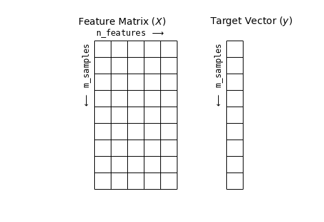

```python
# Figure from the Python Data Science Handbook
plt.show()
```

## 範例資料：Getting Started with Kaggle

## 試著擷取出這些資料的 Target vector 與 Feature matrix

## House Prices: Advanced Regression Techniques

https://www.kaggle.com/c/house-prices-advanced-regression-techniques

```python
# Target Vector: SalePrice

train_url = "https://storage.googleapis.com/kaggle_datasets/House-Prices-Advanced-Regression-Techniques/train.csv"
```

## Titanic: Machine Learning from Disaster

https://www.kaggle.com/c/titanic

```python
# Target Vector: Survived

train_url = "https://storage.googleapis.com/kaggle_datasets/Titanic-Machine-Learning-from-Disaster/train.csv"
```

## Digit Recognizer

https://www.kaggle.com/c/digit-recognizer

```python
# Target Vector: label

train_url = "https://storage.googleapis.com/kaggle_datasets/Digit-Recognizer/train.csv"
```

## Scikit-Learn 的 Estimator

## 每個 Scikit-Learn 的演算法都是一個 Estimator 類別

- 在初始化的時候設定參數

```python
from sklearn.linear_model import LinearRegression

reg = LinearRegression()
print(reg)
```

```
LinearRegression(copy_X=True, fit_intercept=True, n_jobs=1, normalize=False)
```

## 初始化之後將資料輸入進行 `fit`

- Estimator 的屬性命名都以底線結尾

```python
import pandas as pd

data_url = "https://storage.googleapis.com/kaggle_datasets/House-Prices-Advanced-Regression-Techniques/train.csv"
labeled = pd.read_csv(data_url)
X = labeled["GrLivArea"].values.reshape(-1, 1)
y = labeled["SalePrice"].values.reshape(-1, 1)
reg.fit(X, y)
print(reg.intercept_)
print(reg.coef_)
```

```
[ 18569.02585649]
[[ 107.13035897]]
```

```python
import numpy as np
import matplotlib.pyplot as plt

xfit = np.linspace(X.min() - 10, X.max() + 10, 100).reshape(-1, 1)
yfit = reg.predict(xfit)
plt.scatter(X, y, label='data', s=3, color="#4286f4")
plt.plot(xfit, yfit, color="#f4a041", linewidth=2, label='reg')
plt.legend()
```

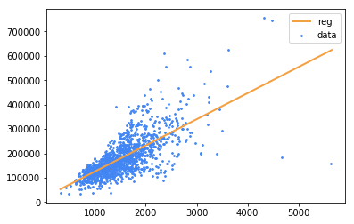

```python
plt.show()
```

## 非演算法也用 Estimator 類別去操作

- 同樣在初始化的時候設定參數
- 如果是預處理，在初始化後將資料輸入做 `fit_transform`

```python
from sklearn.preprocessing import PolynomialFeatures

poly = PolynomialFeatures(degree=7)
X_poly = poly.fit_transform(X)
reg.fit(X_poly, y)
print(reg.intercept_)
print(reg.coef_)
```

```
[ 108657.84974682]
[[  0.00000000e+00   2.44911864e-12   3.01889423e-14   4.35404746e-11
    3.78254367e-08  -2.37317287e-11   5.19276846e-15  -3.85321774e-19]]
```

```python
xfit = np.linspace(X.min() - 10, X.max() + 10, 100).reshape(-1, 1)
xfit_poly = poly.fit_transform(xfit)
yfit = reg.predict(xfit_poly)
plt.scatter(X, y, label='data', s=3, color="#4286f4")
plt.plot(xfit, yfit, color="#f4a041", linewidth=2, label='reg')
plt.legend()
```

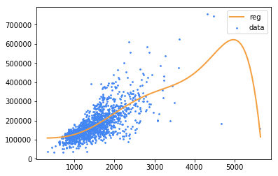

```python
plt.show()
```

## 使用 NumPy 做矩陣運算

## 二維的 ndarray

- 向量：`.reshape(-1, 1)`
- 矩陣：`.reshape(m, n)`
- 轉置：`.T` 屬性或 `np.transpose()`
- 相乘：`.dot()` 或 `np.dot()`
- 反矩陣：`np.linalg.inv()`

## 運算練習

- 練習計算 $u^Tv$

$$u = \begin{bmatrix} 4 \\ -4 \\ -3 \end{bmatrix}$$

$$v = \begin{bmatrix} 4 \\ 2 \\ 4 \end{bmatrix}$$

## 運算練習

- 練習計算 $AB$ 與 $BA$

$$A = \begin{bmatrix} 1 & 2 \\ 4 & 5 \\ \end{bmatrix}$$

$$B = \begin{bmatrix} 4 & 3 \\ 2 & 1 \\ \end{bmatrix}$$